# An Investigation into Causes of Coronary Heart Disease

STAT 112 Final Project

Alexander Denzler, William Moscato, Matthew Polemeni-Hegarty, Erik Hager

10/23/2020

## Introduction

This data set explores the factors that could possibly go into getting Coronary Heart Disease (CHD). CHD is usually caused by the buildup of plaque in the arteries, which in turn limits the blood flow to the heart. It is a disease that can be treated, but cannot be cured at this point. Due to its chronic nature, disease prevention is the most effective treatment. The several graphs below investigate further into several indicators of CHD to see if they have an effect on whether someone is at risk of CHD. This will allow us to control for our primary goal to determine whether this data can further prove that smoking has an effect on CHD.

## Data Collection

The data used in this analysis was collected from [Kaggle](https://www.kaggle.com/dileep070/heart-disease-prediction-using-logistic-regression). This data has been collected using participants from Framingham, Massachussetts. This data set tracks whether a participant is at risk for coronary heart disease (CHD) through several risk indicators. The indicating variables in this data set include : age, gender, whether or not the person smokes, how many cigarettes they smoke per day, whether they take blood pressure medication, if they have had a stroke, if they have diabetes, if they have hypertension, systolic and diastolic blood pressure, cholesterol, heart rate, and glucose levels.

## Analysis

### Investigating the Data

In this section we are going to investigate different indicator variables in order to determine which variables have the most significant impact on CHD risk. This will allow us to determine whether smoking cigarettes has a significant impact on CHD risk.

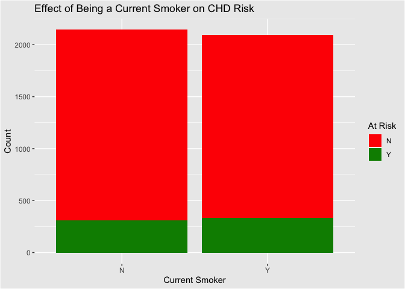

In this first plot, we are observing the trend between current smokers and their risk for coronary heart disease at an extremely high level. This one plot does not tell us too much, except for the fact that more current smokers are at risk of coronary heart disease, which is to be expected. The purpose of this plot is to investigate the data further.

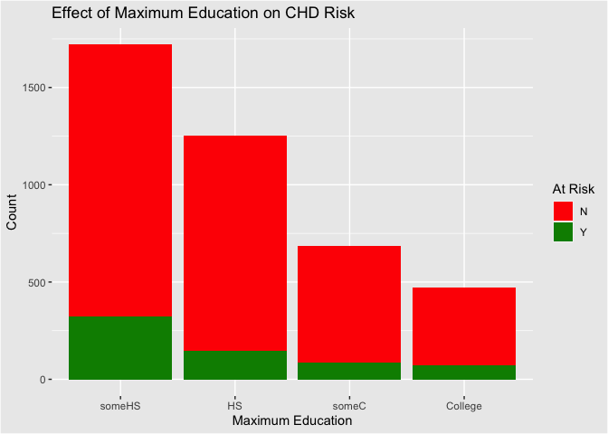

Next, we compared education level with heart disease risk. This plot is similar to the first in that we must explore the indicator variables in order to conduct our analysis. However, it does tell an interesting story about how maximum education affects whether or not someone is at risk for coronary heart disease. Although this plot conveys that one's education level achieved determines the risk someone for CHD, this is not necessarily the case proportionally. In the graph below we look at the education level proportions and find that there is a higher proportion of people who are college educated who are at risk for CHD than people who have some college education or a completed high school education.

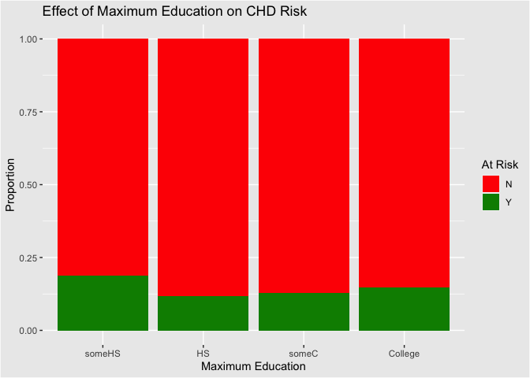

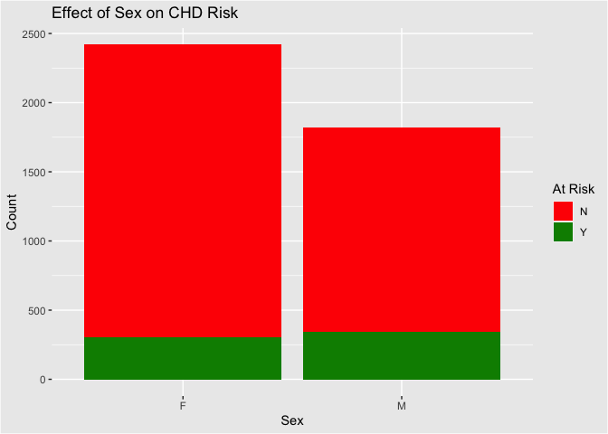

Next, we wanted to investigate whether sex had an effect on coronary heart disease risk. This plot conveys much cleaner results than previous plots. Here, we can clearly see that not only men are at a greater risk for CHD, the proportion of men who are at risk is also much higher than that of women.

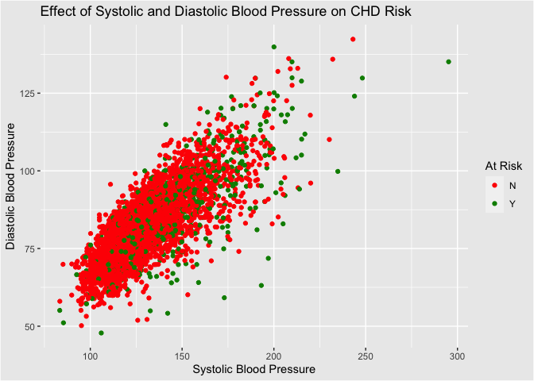

In this plot, we are looking at the effects of blood pressure levels on whether or not a participant is at risk. Here, it is not completly clear whether the majority of at risk participants are towards the higher end of the plot, however it does look as if there are more participants who are not at risk towards the lower left quadrant of the graph. Logically, it would make sense to assume that people with higher blood pressure are more likely to be at risk for CHD, given that high blood pressure is generally one of the most telling signs of heart complications.

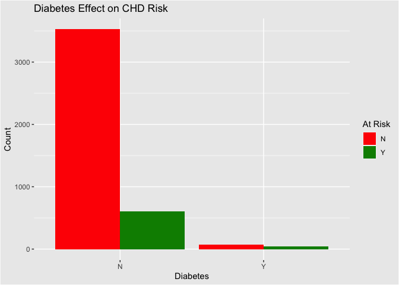

In this graph, we compare the proportions of subjects with and without heart disease between those who have diabetes and those who do not. Among those with diabetes, it appears that about one-third are at risk for heart disease. Compared to the participants who do not have diabetes, this proportion is far greater. Thus, it appears that diabetes is a significant indicator of CHD risk.

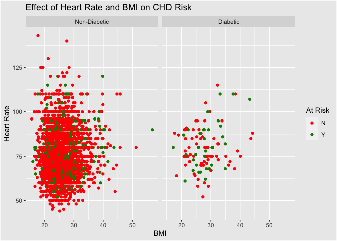

This graph displays the various BMI and heart rates of participants who display signs of heart disease risk. This graph is also faceted by participants who are diabetic or not. This allows us to determine whether heart rate and BMI have a greater influence in CHD risk for individuals who are already diagnosed with a chronic disease. As conveyed in the previous graph, the majority of the participants are not diabetic, however it is once again clear there is a significantly higher proportion of individuals with heart disease among the diabetic group. Despite this proportion, this graph does not appear to display a noticeable correlation between CHD, BMI, and heart rate. This allows us to conclude that diabetes is a greater indicator for CHD than BMI and heart rate for the participants in this data set.

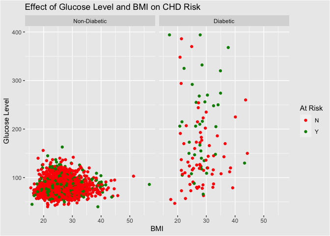

Next we wanted to create a graph that displays the various BMI and glucose levels of participants with and without heart disease, faceted by diabetes diagnosis. It is hard to determine whether there is a noticeable correlation between CHD and glucose levels in the non-diabetic group, but it appears that participants with higher glucose levels in the diabetic group were more likely to have heart disease than diabetic participants with lower glucose levels. It is also interesting to note that the glucose levels in diabetic participants is far higher than that of no diabetic participants. This logically makes sense because a main symptom of diabetes is the inability to process glucose from the bloodstream.

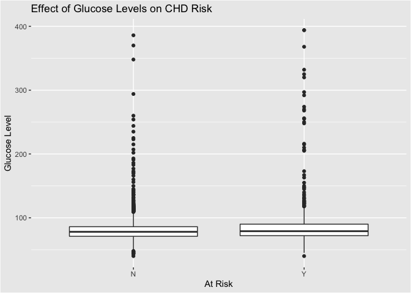

In order to get a greater understanding the effect of glucose on CHD risk we isolated glucose into two side by side boxplots that are sorted by at risk and not at risk. Surprisingly there seems to be a significant difference between the IQR when looking at glucose levels compared to cholesterol levels. The at risk median is also slightly greater than the not at risk median. There are also quite a few outliers. These outliers can probably explain the larger 75th percentile of the interquartile range.

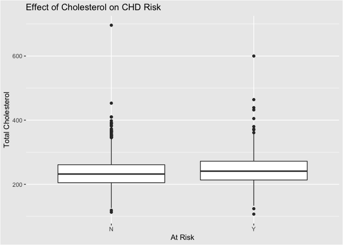

Similar to the graph of glucose, we also created another side by side boxplot comparison that shows participant's total cholesterol levels split up by whether or not someone is at risk for CHD. What we see here is that the median cholesterol level for people who are at risk is higher than that of participants who are not at risk. We are also able to see that the difference between the 25th percentile and 75th percentile, otherwise known as the interquartile range (IQR), is roughly the same size for both people who are and aren't at risk. Once again, both plots experience some pretty significant outliers.

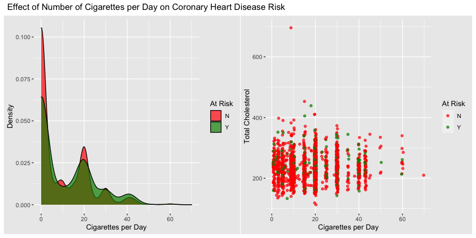

Finally, we wanted to address our main focus by graphing the effect of cigarette usage on risk of CHD. We used a density plot on the left and a jitter plot on the right that uses cholesterol as an explanatory variable. The density plot shows us that at risk participants smoke more cigarettes than those who are not at risk. It is also seen in both plots that the number of cigarettes smoked per day is somewhat organized into multiples of five. This makes sense because we assumed that the data collected is an estimation of cigarettes per day not an exact study. Therefore, we experience a stratified distribution. Similarly, out of the participants who smoke, the majority smoke 20 cigarettes a day. This is likely the case because there are 20 cigarettes in a single pack. These participants likely stated that they smoke about a pack a day. Although these graphs provide results that show people who smoke are at a greater risk for CHD, we wanted to isolate smoking by controlling for the other indicators of CHD as well as incorporate other factors that could impact CHD.

### Variable Importance

We can see from the graphs above that in this data set the most prevalent variables in predicting risk of CHD are education, diabetes, glucose levels, cholesterol levels, and how many cigarettes you smoke. We can see this by the fact that the proportions of people who have ten year risk of CHD is higher when these things are abnormal, or for in the case of education it is significantly different for different levels. In order to see how cigarettes actually effect risk of CHD, we will control for all of these variables other than how many cigarettes you smoke.

### Controlled Graph

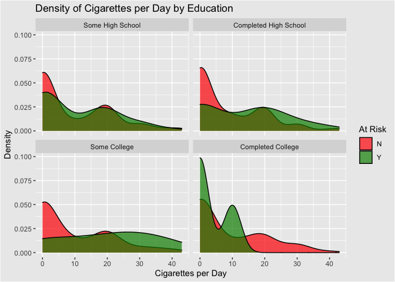

This graph conveys the results of how smoking effects CHD risk while controlling for other prevalent indicators. We did this by filtering cholesterol and glucose levels so that the graph only reflects "healthy" participants. We determined that a normal glucose level is below 140, while a normal cholesterol level is between 125 and 200. We also filtered the diabetes variable to reflect participants in the study that do not have diabetes. By controlling for these variables, we are able to manipulate the data in order to reflect a more accurate depiction of the effect of cigarette smoking on causing CHD in otherwise healthy individuals.

The results of this graph are quite interesting. We can see that there is a much clearer depiction of the effect of smoking on CHD. This graph shows that there is a greater density of participants who are at risk when participants smoke more than 10 cigarettes per day. However, this is not the case for participants who have completed college. The faceted graph that depicts college educated participants shows that almost all the participants who smoke over 15 cigarettes per day are in the not at risk category. We have deduced a few possibilities for why this is the case. For participants who are at risk of CHD, finishing their college education plays a large role in CHD risk. Participants who have not completed college in this data set seem to have a greater likelihood of being at risk for CHD. This is once again prevalent in these graphs. Therefore, we think that there are other factors that can impact CHD risk that are related to education level. Traditionally, education is often linked to one's socioeconomic class. If this is the case, then we may be able to make some assumptions for why CHD risk is greater for non-college educated participants. For example, access to proper nutrition and exercise could be a significant factor in one's CHD risk. Historically, people who are in middle to lower socioeconomic class have less access to nutritional foods and sufficient exercise. Similarly, food insecurity and low income can also cause the negative externalities. We believe that the variables provided in this data set are unable to show the whole story about smoking's effect on CHD risk, however provide sufficient evidence that smoking increases CHD risk.

## Conclusion

In conclusion, we can see that smoking is a factor for being at risk for coronary heart disease. As we covered in the introduction, there is no cure for CHD, so the best thing that we can do is prevent it. From the data we can see the best way to prevent CHD is to maintain healthy cholesterol and glucose levels through proper diet, regular exercise and other healthy life choices. Doing so will also limit risk for diabetes. Participants who were diabetic had the greatest proportion of participants be at risk for CHD. Despite a healthy diet and exercise, it was still prevalent that smoking will greatly increase your risk for CHD. Normally, smoking is associated with other chronic diseases such as cancer, lung disease, and throat disease, but it is important to note that smoking has many other adverse effects such as increasing risk of CHD.

## Appendix

This appendix shows the original data set we intended to use, as well as the plots we created to investigate the data.

These graphs are raw and unfiltered, however may provide additional insight into the analysis we provided.

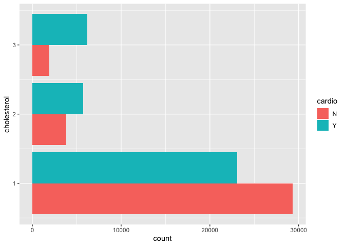

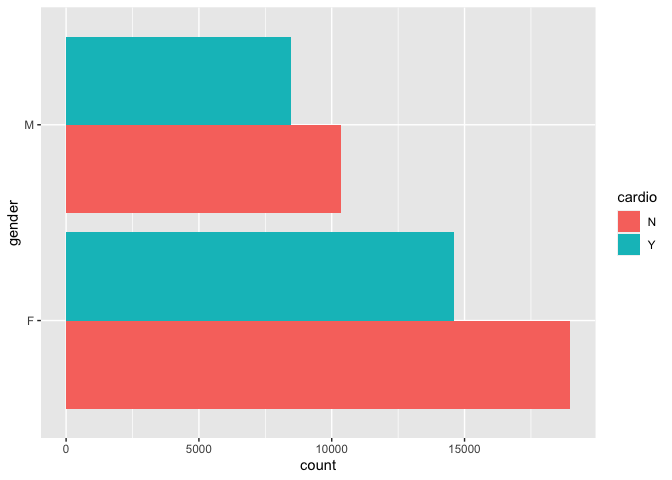

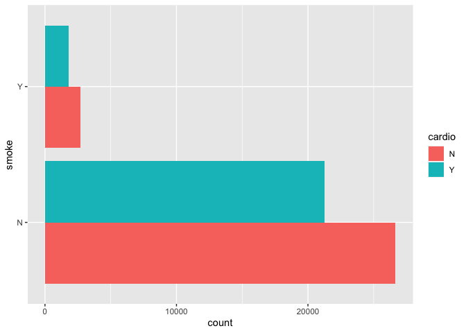

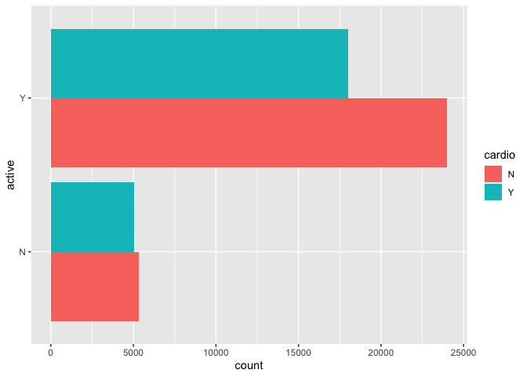

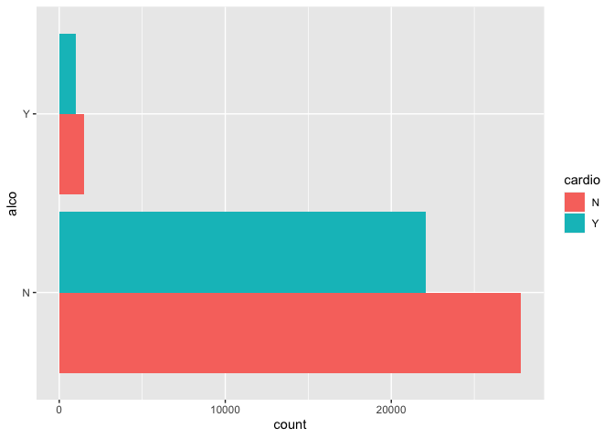

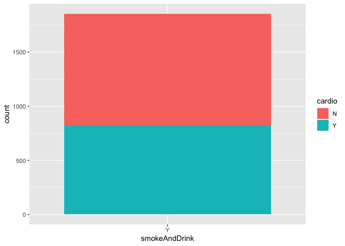